# Coffee Rating Analysis - Lisa Hernandez

2024-06-21

## Coffee Rating Analysis Using Bayesian Modeling

### Lisa Hernandez

```r
# Load packages
library(bayesrules)
library(tidyverse)
library(rstan)
library(rstanarm)
```

```r
library(bayesplot)
library(tidybayes)
library(janitor)
library(broom.mixed)
```

```r
#load the dataset
data("coffee_ratings")
coffee_ratings <- coffee_ratings %>%
  select(farm_name, total_cup_points, aroma, aftertaste)
```

### Getting started with coffee ratings

Before doing any modeling, let’s get to know the coffee_ratings data.

The coffee_ratings data includes ratings and features of 1339 different batches of beans grown on 571 different farms.

Using this data to model ratings (total_cup_points) likely violates the independence assumption of the Bayesian linear regression model because there are several observations from each farm that could be related. Because of this, we will create a new data set that takes one observation per farm that way we can have independent variables for this analysis.

```r
head(coffee_ratings)
```

```
## # A tibble: 6 × 4
##   farm_name                                   total_cup_points aroma aftertaste
##   <fct>                                                  <dbl> <dbl>      <dbl>
## 1 "metad plc"                                             90.6  8.67       8.67
## 2 "metad plc"                                             89.9  8.75       8.5
## 3 "san marcos barrancas \"san cristobal cuch"             89.8  8.42       8.42
## 4 "yidnekachew dabessa coffee plantation"                 89    8.17       8.42
## 5 "metad plc"                                             88.8  8.25       8.25
## 6  <NA>                                                   88.8  8.58       8.42
```

```r
set.seed(84735)
new_coffee <- coffee_ratings %>%
  group_by(farm_name) %>%
  sample_n(1) %>%
  ungroup()
dim(new_coffee)
```

```
## [1] 572   4
```

### Modeling Coffee Ratings - Bayesian Normal Regression Model

Our data model is: Yi | β0, β1, σ ~ind N(μi, σ^2)

And the priors of the parameters are: μi=β0+β1X

β0~N(m0,s2/0)

β1~N(m1,s2/1)

σ ~Exp(l)

I will use a coffee bean’s rating (Y) by its aroma grade (X) with μi=β0+β1X. In doing so, I assume that our only prior understanding is that the average cup of coffee has a 75-point rating, though this might be anywhere between 55 and 95. Beyond that, I will utilize weakly informative priors.

This means β0 is most likely 75, with its 95% CI boundaries being 95 and 55. This further means that 2s0=20=> s0=10.

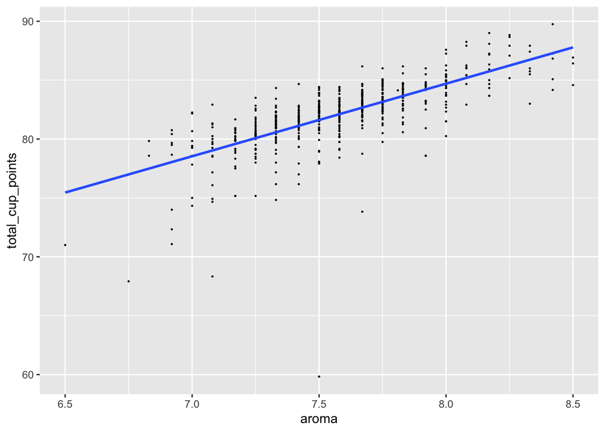

```r
#plotting the relationship between total_cup_points and aroma
ggplot(new_coffee, aes(y = total_cup_points, x = aroma)) +
  geom_point(size = 0.2) +
  geom_smooth(method = "lm", se = FALSE)
```

We can see from the graph that the total cup points and aroma have a linear relationship. This means that the higher the grade of coffee aroma, the higher the total cup points will be.

Using stan_glm() to simulate the Normal regression posterior model.

```r
summary(new_coffee)
```

```
##         farm_name   total_cup_points     aroma         aftertaste
##  -           :  1   Min.   :59.83    Min.   :6.500   Min.   :6.170
##  1           :  1   1st Qu.:80.92    1st Qu.:7.330   1st Qu.:7.170
##  200 farms   :  1   Median :82.33    Median :7.580   Median :7.420
##  2000 farmers:  1   Mean   :82.10    Mean   :7.578   Mean   :7.395
##  2000 farms  :  1   3rd Qu.:83.58    3rd Qu.:7.750   3rd Qu.:7.580
##  (Other)     :566   Max.   :89.75    Max.   :8.500   Max.   :8.580
##  NA's        :  1
```

```r
coffee_model <- stan_glm(total_cup_points ~ aroma, data = new_coffee,
                       family = gaussian,
                       prior_intercept = normal(75, 10, autoscale = TRUE),
                       prior = normal(7.5, 0.5, autoscale = TRUE),
                       prior_aux = exponential(1, autoscale = TRUE),
                       chains = 4, iter = 5000*2, seed = 84735)
```

*Providing visual and numerical posterior summaries for the `aroma` coefficient*.

```r
#prior
summary(coffee_model)
```

```
##
## Model Info:
##  function:     stan_glm
##  family:       gaussian [identity]
##  formula:      total_cup_points ~ aroma
##  algorithm:    sampling
##  sample:       20000 (posterior sample size)
##  priors:       see help('prior_summary')
##  observations: 572
##  predictors:   2
##
## Estimates:
##               mean   sd   10%   50%   90%
## (Intercept) 35.4    2.0 32.9  35.4  37.9
## aroma        6.2    0.3  5.8   6.2   6.5
## sigma        2.0    0.1  1.9   2.0   2.0
##
## Fit Diagnostics:
##            mean   sd   10%   50%   90%
## mean_PPD 82.1    0.1 82.0  82.1  82.2
##
## The mean_ppd is the sample average posterior predictive distribution of the outcome variable (for details see help('summary.stanreg')).
##
## MCMC diagnostics
##               mcse Rhat n_eff
## (Intercept)   0.0  1.0  20715
## aroma         0.0  1.0  20747
## sigma         0.0  1.0  20326
## mean_PPD      0.0  1.0  19674
## log-posterior 0.0  1.0   8913
##
## For each parameter, mcse is Monte Carlo standard error, n_eff is a crude measure of effective sample size, and Rhat is the potential scale reduction factor on split chains (at convergence Rhat=1).
```

```r
prior_summary(coffee_model)
```

```
## Priors for model 'coffee_model'
## ------
## Intercept (after predictors centered)
##   Specified prior:
##     ~ normal(location = 75, scale = 10)
##   Adjusted prior:
##     ~ normal(location = 75, scale = 27)
##
## Coefficients
##   Specified prior:
##     ~ normal(location = 7.5, scale = 0.5)
##   Adjusted prior:
##     ~ normal(location = 7.5, scale = 4.4)
##
## Auxiliary (sigma)
##   Specified prior:
##     ~ exponential(rate = 1)
##   Adjusted prior:
##     ~ exponential(rate = 0.36)
## ------
## See help('prior_summary.stanreg') for more details
```

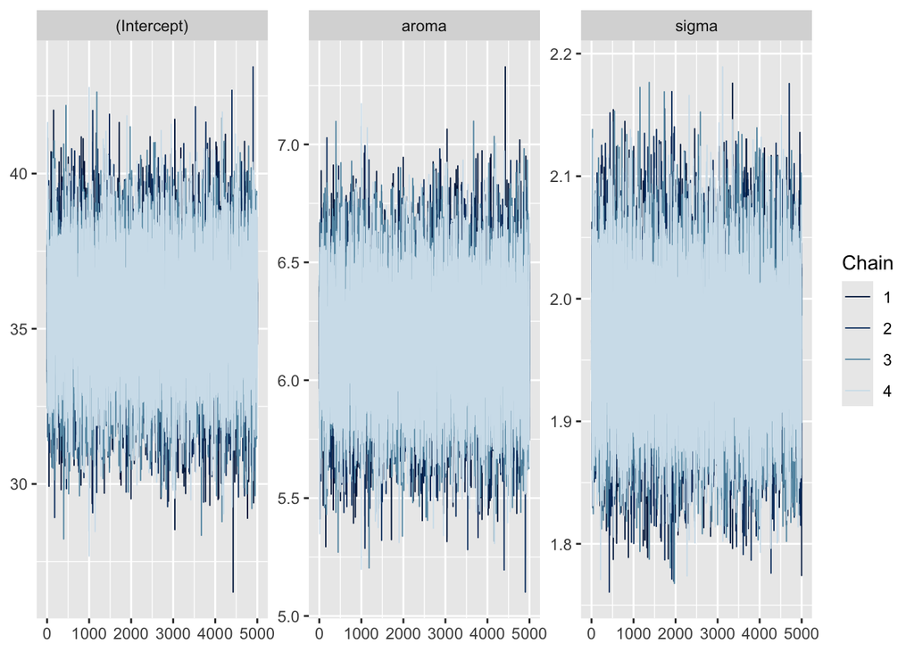

```r
mcmc_trace(coffee_model)
```

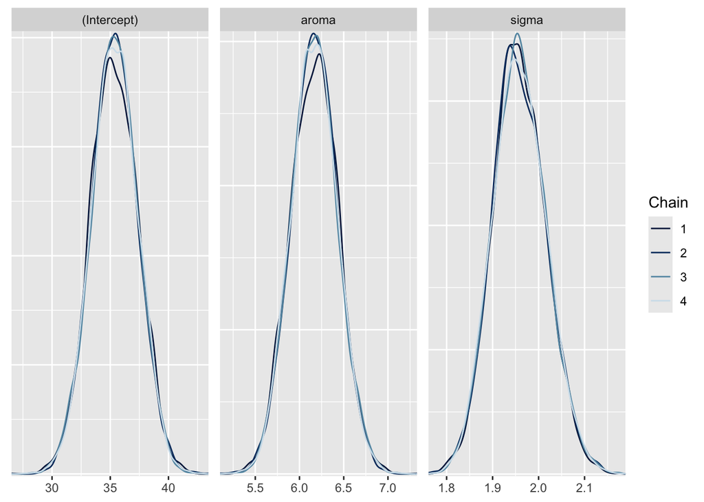

```r
mcmc_dens_overlay(coffee_model)
```

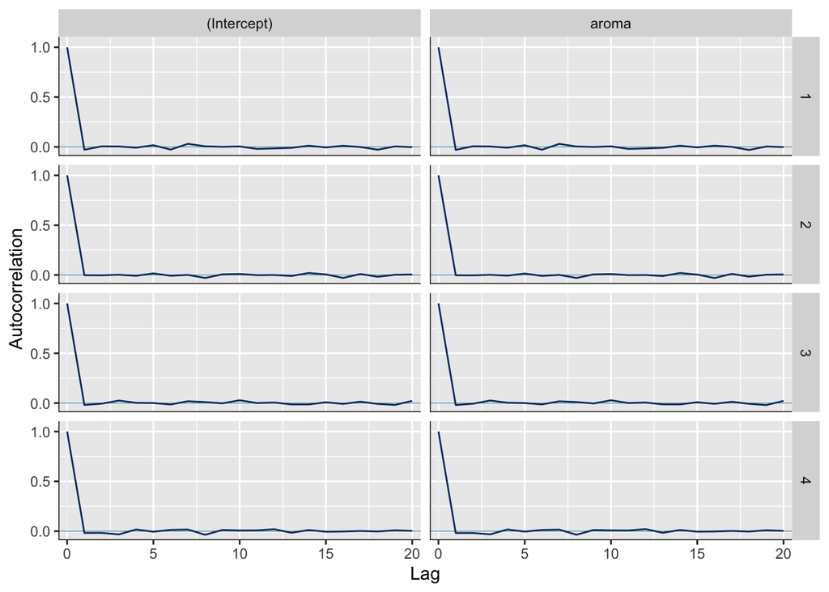

```r
mcmc_acf(coffee_model, pars = c("(Intercept)", "aroma"))
```

We can see that all three sets of graphs shows a stable MCMC with each of the chains overlaping suggesting that each of them have come to about the same posterior probability which is close to zero.

```r
#simulating the posterior model
coffee_model_posterior <- stan_glm(
  formula = total_cup_points ~ aroma, data = new_coffee,
  family = gaussian,
  prior_intercept = normal(75, 27, autoscale = TRUE),
  prior = normal(7.5, 4.4, autoscale = TRUE),
  prior_aux = exponential(0.36, autoscale = TRUE),
  chains = 4,
  iter = 5000*2,
  seed = 84735,
  prior_PD = FALSE)
summary(coffee_model_posterior)
```

```
##
## Model Info:
##  function:     stan_glm
##  family:       gaussian [identity]
##  formula:      total_cup_points ~ aroma
##  algorithm:    sampling
##  sample:       20000 (posterior sample size)
##  priors:       see help('prior_summary')
##  observations: 572
##  predictors:   2
##
## Estimates:
##               mean   sd   10%   50%   90%
## (Intercept) 35.4    2.0 32.9  35.4  37.9
## aroma        6.2    0.3  5.8   6.2   6.5
## sigma        2.0    0.1  1.9   2.0   2.0
##
## Fit Diagnostics:
##            mean   sd   10%   50%   90%
## mean_PPD 82.1    0.1 81.9  82.1  82.2
##
## The mean_ppd is the sample average posterior predictive distribution of the outcome variable (for details see help('summary.stanreg')).
##
## MCMC diagnostics
##               mcse Rhat n_eff
## (Intercept)   0.0  1.0  18861
## aroma         0.0  1.0  18825
## sigma         0.0  1.0  19041
## mean_PPD      0.0  1.0  19476
## log-posterior 0.0  1.0   9509
##
## For each parameter, mcse is Monte Carlo standard error, n_eff is a crude measure of effective sample size, and Rhat is the potential scale reduction factor on split chains (at convergence Rhat=1).
```

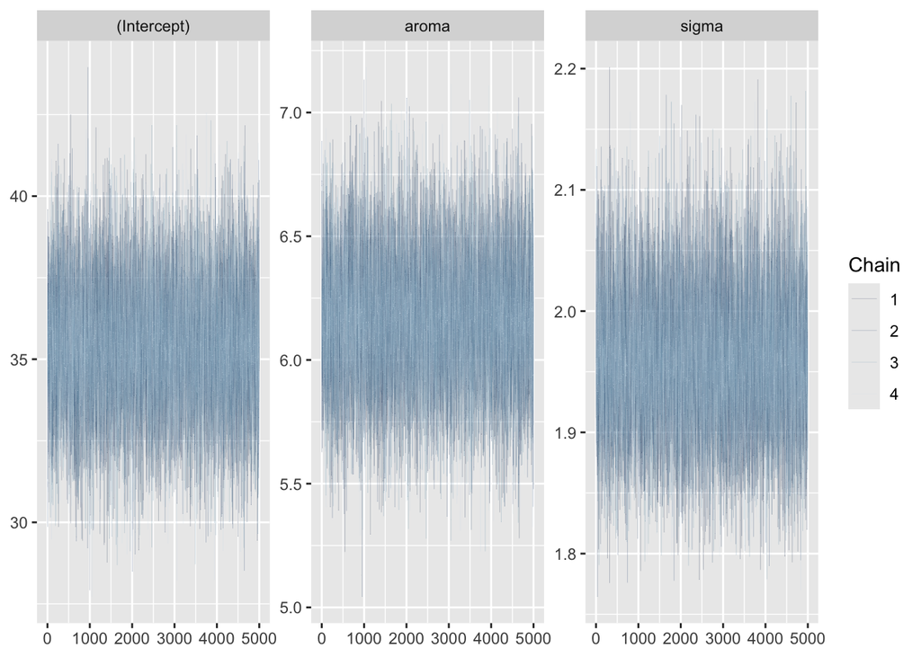

```r
mcmc_trace(coffee_model_posterior, size = 0.1)
```

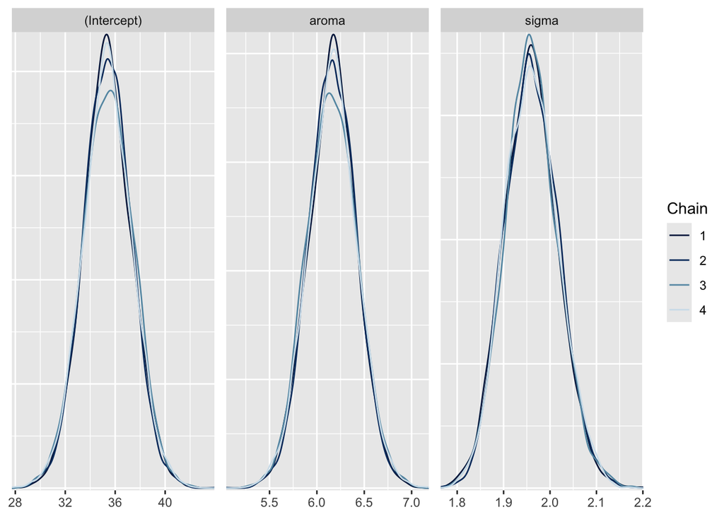

```r
mcmc_dens_overlay(coffee_model_posterior)
```

```r
tidy(coffee_model_posterior,
     effects = c("fixed", "aux"),
     conf.int = TRUE,
     conf.level = 0.95)
```

```
## # A tibble: 4 × 5
##   term        estimate std.error conf.low conf.high
##   <chr>          <dbl>     <dbl>    <dbl>     <dbl>
## 1 (Intercept)    35.4     1.94      31.5      39.2
## 2 aroma           6.16    0.257      5.66      6.67
## 3 sigma           1.96    0.0578     1.85      2.08
## 4 mean_PPD       82.1     0.117     81.9      82.3
```

```r
coffee_model_df <- as.data.frame(coffee_model_posterior)

nrow(coffee_model_df)
```

```
## [1] 20000
```

```r
head(coffee_model_df, 3)
```

```
##   (Intercept)    aroma    sigma
## 1    38.68915 5.751978 2.031340
## 2    31.32528 6.683129 1.912095
## 3    39.59190 5.627941 1.961472
```

Providing visual and numerical posterior summaries for the aroma coefficient β1.

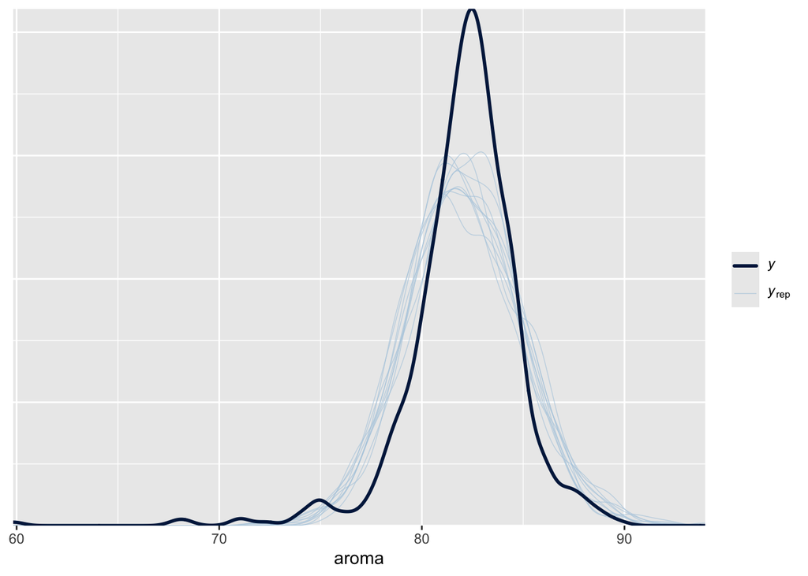

```r
pp_check(coffee_model_posterior, nreps = 10) +
  xlab("aroma")
```

The graph shows that there is some inconsistencies between the observed and simulated values between total_cup_points and aroma. This is likely because of the parameters that were computed.

```r
summary(coffee_model_posterior)
```

```
##
## Model Info:
##  function:     stan_glm
##  family:       gaussian [identity]
##  formula:      total_cup_points ~ aroma
##  algorithm:    sampling
##  sample:       20000 (posterior sample size)
##  priors:       see help('prior_summary')
##  observations: 572
##  predictors:   2
##
## Estimates:
##               mean   sd   10%   50%   90%
## (Intercept) 35.4    2.0 32.9  35.4  37.9
## aroma        6.2    0.3  5.8   6.2   6.5
## sigma        2.0    0.1  1.9   2.0   2.0
##
## Fit Diagnostics:
##            mean   sd   10%   50%   90%
## mean_PPD 82.1    0.1 81.9  82.1  82.2
##
## The mean_ppd is the sample average posterior predictive distribution of the outcome variable (for details see help('summary.stanreg')).
##
## MCMC diagnostics
##               mcse Rhat n_eff
## (Intercept)   0.0  1.0  18861
## aroma         0.0  1.0  18825
## sigma         0.0  1.0  19041
## mean_PPD      0.0  1.0  19476
## log-posterior 0.0  1.0   9509
##
## For each parameter, mcse is Monte Carlo standard error, n_eff is a crude measure of effective sample size, and Rhat is the potential scale reduction factor on split chains (at convergence Rhat=1).
```

```r
#posterior values
coffee_model_posterior
```

```
## stan_glm
##  family:       gaussian [identity]
##  formula:      total_cup_points ~ aroma
##  observations: 572
##  predictors:   2
## ------
##             Median MAD_SD
## (Intercept) 35.4    1.9
## aroma        6.2    0.3
##
## Auxiliary parameter(s):
##       Median MAD_SD
## sigma 2.0    0.1
##
## ------
## * For help interpreting the printed output see ?print.stanreg
## * For info on the priors used see ?prior_summary.stanreg
```

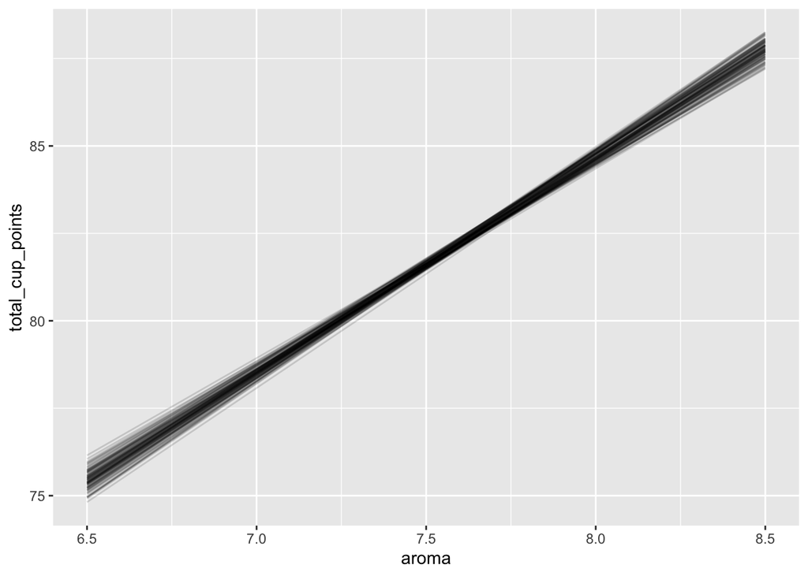

```r
new_coffee %>%
  add_fitted_draws(coffee_model_posterior, n = 100) %>%
  ggplot(aes(y = total_cup_points, x = aroma)) +
    geom_line(aes(y = .value, group = .draw), alpha = 0.15)
```

From the summary and the graph above, we can conclude that there is significant posterior evidence in order to proceed that the better a coffee bean’s aroma, the higher its rating tends to be. The Rhat values are 1.0 meaning that the posterior PDFs are stable and based on the observed mean of aroma being significantly larger than zero.

### Coffee Ratings: Is it wrong?

Before we put too much stock into the regression analysis, we will step back and consider whether it’s wrong.

The posterior simulation contains multiple sets of posterior plausible parameter sets, (β0,β1,σ). We will use the first of these to simulate a sample of 572 new coffee ratings from the observed aroma grades.

```r
first_set <- head(coffee_model_df, 1)
first_set
```

```
##   (Intercept)    aroma   sigma
## 1    38.68915 5.751978 2.03134
```

```r
beta_0 <- first_set$`(Intercept)`
beta_1 <- first_set$aroma
sigma  <- first_set$sigma
set.seed(84735)
one_simulation <- new_coffee %>%
  mutate(mu = beta_0 + beta_1 * aroma,
         simulated_points = rnorm(572, mean = mu, sd = sigma)) %>%
  select(aroma, total_cup_points, simulated_points)
```

```r
head(one_simulation, 2)
```

```
## # A tibble: 2 × 3
##   aroma total_cup_points simulated_points
##   <dbl>            <dbl>            <dbl>
## 1  7.67             84               84.2
## 2  7.33             76.2             80.6
```

Next we will construct a density plot of the simulated sample and superimpose this with a density plot of the actual observed total_cup_points data.

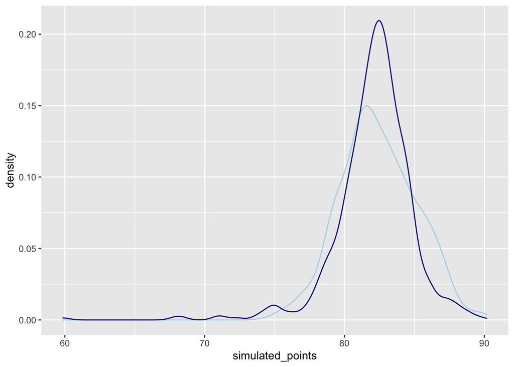

```r
ggplot(one_simulation, aes(x = simulated_points)) +
  geom_density(color = "lightblue") +
  geom_density(aes(x = total_cup_points), color = "darkblue")
```

The simulated points seem to have less of a density that the original data points, though it does seem to have semi-similar spread.

we will use pp_check() to implement a more complete posterior predictive check.

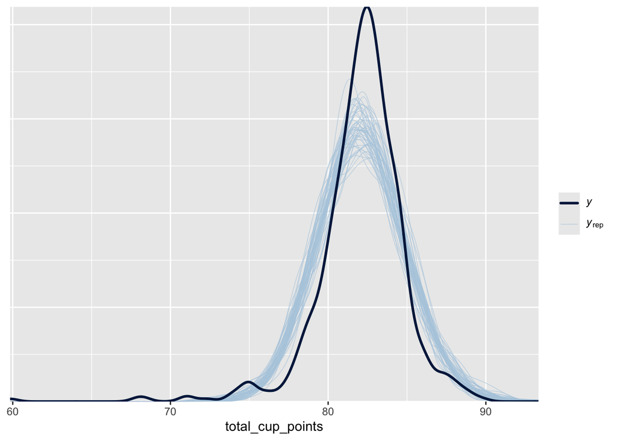

```r
pp_check(coffee_model_posterior, nreps = 50) +
  xlab("total_cup_points")
```

I would count this model as reasonable because the predictions get a decent capture of the total cup points with the form of the graph, even though the density seems to be a bit different.

### Coffee ratings: Are the posterior predictions accurate?

Next, let’s explore how well our posterior model predicts coffee bean ratings.

The first batch of coffee beans in new_coffee has an aroma grade of 7.67. We will simulate and plot a posterior predictive model for the rating of this batch.

```r
new_coffee %>%
  filter(aroma == "7.67") %>%
  select(total_cup_points)
```

```
## # A tibble: 68 × 1
##    total_cup_points
##               <dbl>
##  1             84
##  2             83.7
##  3             82.9
##  4             82.1
##  5             82.7
##  6             83.6
##  7             82.8
##  8             82.5
##  9             82.2
## 10             81.5
## # ℹ 58 more rows
```

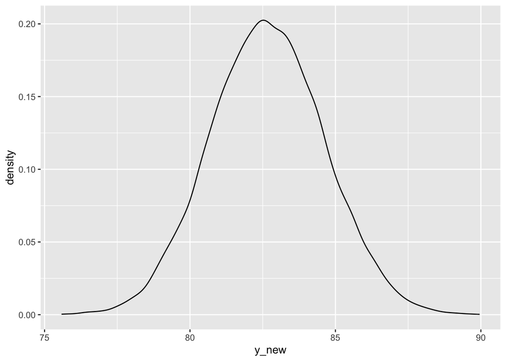

```r
set.seed(84735)
predict_767 <- coffee_model_df %>%
  mutate(mu = `(Intercept)` + aroma*7.67,
         y_new = rnorm(20000, mean = mu, sd = sigma))

# Plot the posterior predictive model
ggplot(predict_767, aes(x = y_new)) +
  geom_density()
```

This batch of beans had a rating of 84. Now we will calculate and interpret two measures of the posterior predictive error for this batch: both the raw and standardized error.

```r
predict_767 %>%
  summarize(mean = mean(y_new), error = 84 - mean(y_new))
```

```
##       mean    error
## 1 82.66273 1.337272
```

```r
predict_767 %>%
  summarize(sd = sd(y_new), error = 84 - mean(y_new),
            error_scaled = error / sd(y_new))
```

```
##         sd    error error_scaled
## 1 1.954997 1.337272    0.6840274
```

To get a sense of the posterior predictive accuracy for all batches in new_coffee, we will construct and discuss a ppc_intervals() plot.

```r
set.seed(84735)
predictions <- posterior_predict(coffee_model_posterior, newdata = new_coffee)
dim(predictions)
```

```
## [1] 20000   572
```

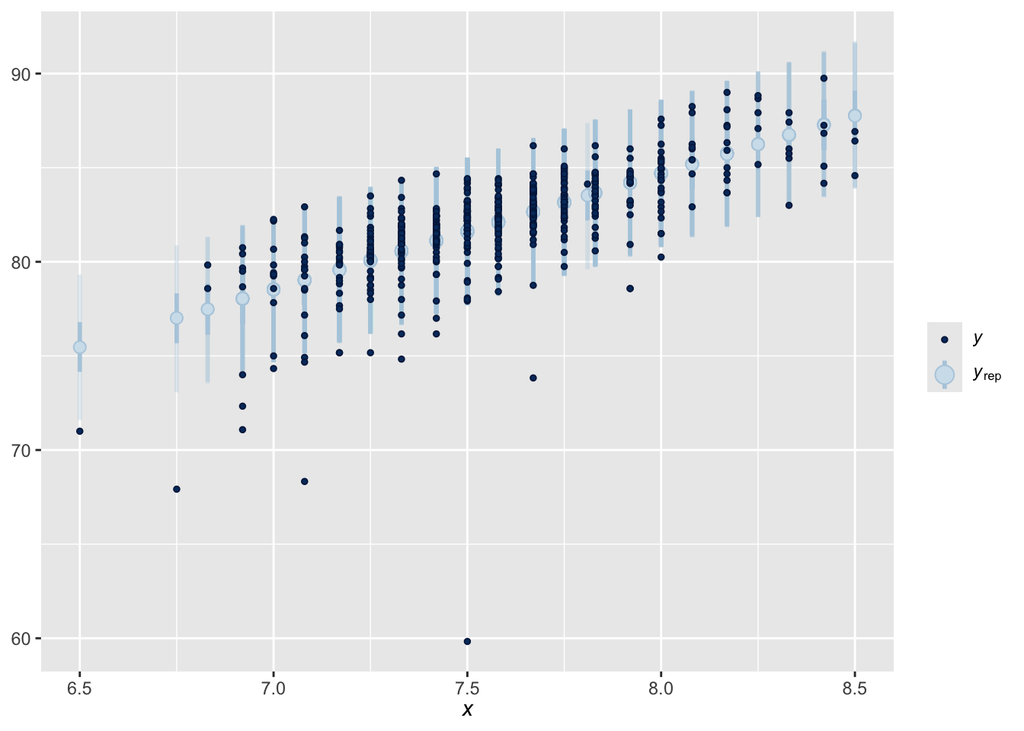

```r
ppc_intervals(new_coffee$total_cup_points, yrep = predictions, x = new_coffee$aroma,
              prob = 0.5, prob_outer = 0.95)
```

As the aroma grading gets higher we can see that the y points are on the y rep scale.

```r
set.seed(84735)
prediction_summary(coffee_model_posterior, data = new_coffee)
```

```
##         mae mae_scaled within_50 within_95
## 1 0.8777563  0.4481957 0.6888112 0.9597902
```

It looks like 68.9% of the batches remain in the 50% prediction interval.

### Coffee ratings Now with Aftertaste!

Aroma isn’t the only possible predictor of a coffee bean’s rating. What if, instead, we were to predict rating by a bean’s aftertaste? In exploring this relationship, we will continue to utilize the same prior models.

Using stan_glm() to simulate the Normal regression posterior model of total_cup_points by aftertaste.

```r
summary(new_coffee)
```

```
##         farm_name   total_cup_points     aroma         aftertaste
##  -           :  1   Min.   :59.83    Min.   :6.500   Min.   :6.170
##  1           :  1   1st Qu.:80.92    1st Qu.:7.330   1st Qu.:7.170
##  200 farms   :  1   Median :82.33    Median :7.580   Median :7.420
##  2000 farmers:  1   Mean   :82.10    Mean   :7.578   Mean   :7.395
##  2000 farms  :  1   3rd Qu.:83.58    3rd Qu.:7.750   3rd Qu.:7.580
##  (Other)     :566   Max.   :89.75    Max.   :8.500   Max.   :8.580
##  NA's        :  1
```

```r
coffee_model2 <- stan_glm(total_cup_points ~ aftertaste, data = new_coffee,
                       family = gaussian,
                       prior_intercept = normal(75, 10, autoscale = TRUE),
                       prior = normal(7.3, 0.1, autoscale = TRUE),
                       prior_aux = exponential(1, autoscale = TRUE),
                       chains = 4, iter = 5000*2, seed = 84735)
prior_summary(coffee_model2)
```

```
## Priors for model 'coffee_model2'
## ------
## Intercept (after predictors centered)
##   Specified prior:
##     ~ normal(location = 75, scale = 10)
##   Adjusted prior:
##     ~ normal(location = 75, scale = 27)
##
## Coefficients
##   Specified prior:
##     ~ normal(location = 7.3, scale = 0.1)
##   Adjusted prior:
##     ~ normal(location = 7.3, scale = 0.81)
##
## Auxiliary (sigma)
##   Specified prior:
##     ~ exponential(rate = 1)
##   Adjusted prior:
##     ~ exponential(rate = 0.36)
## ------
## See help('prior_summary.stanreg') for more details
```

```r
coffee_model_posterior2 <- stan_glm(
  formula = total_cup_points ~ aftertaste, data = new_coffee,
  family = gaussian,
  prior_intercept = normal(75, 27, autoscale = TRUE),
  prior = normal(7.3, 0.81, autoscale = TRUE),
  prior_aux = exponential(0.36, autoscale = TRUE),
  chains = 4,
  iter = 5000*2,
  seed = 84735,
  prior_PD = FALSE)
summary(coffee_model_posterior2)
```

```
##
## Model Info:
##  function:     stan_glm
##  family:       gaussian [identity]
##  formula:      total_cup_points ~ aftertaste
##  algorithm:    sampling
##  sample:       20000 (posterior sample size)
##  priors:       see help('prior_summary')
##  observations: 572
##  predictors:   2
##
## Estimates:
##               mean   sd   10%   50%   90%
## (Intercept) 33.1    1.4 31.3  33.1  34.9
## aftertaste   6.6    0.2  6.4   6.6   6.9
## sigma        1.6    0.0  1.5   1.6   1.6
##
## Fit Diagnostics:
##            mean   sd   10%   50%   90%
## mean_PPD 82.1    0.1 82.0  82.1  82.2
##
## The mean_ppd is the sample average posterior predictive distribution of the outcome variable (for details see help('summary.stanreg')).
##
## MCMC diagnostics
##               mcse Rhat n_eff
## (Intercept)   0.0  1.0  20578
## aftertaste    0.0  1.0  20605
## sigma         0.0  1.0  19758
## mean_PPD      0.0  1.0  19953
## log-posterior 0.0  1.0   8554
##
## For each parameter, mcse is Monte Carlo standard error, n_eff is a crude measure of effective sample size, and Rhat is the potential scale reduction factor on split chains (at convergence Rhat=1).
```

```r
tidy(coffee_model_posterior2,
     effects = c("fixed", "aux"),
     conf.int = TRUE,
     conf.level = 0.95)
```

```
## # A tibble: 4 × 5
##   term        estimate std.error conf.low conf.high
##   <chr>          <dbl>     <dbl>    <dbl>     <dbl>
## 1 (Intercept)    33.1     1.44      30.3      35.9
## 2 aftertaste      6.62    0.195      6.25      7.00
## 3 sigma           1.57    0.0463     1.48      1.66
## 4 mean_PPD       82.1     0.0934    81.9      82.3
```

```r
coffee_model_df2 <- as.data.frame(coffee_model_posterior2)

nrow(coffee_model_df2)
```

```
## [1] 20000
```

```r
head(coffee_model_df2, 3)
```

```
##   (Intercept) aftertaste    sigma
## 1    35.07325   6.356896 1.671128
## 2    33.55107   6.563899 1.620554
## 3    32.76697   6.669593 1.503043
```

Producing a quick plot to determine whether this model is wrong.

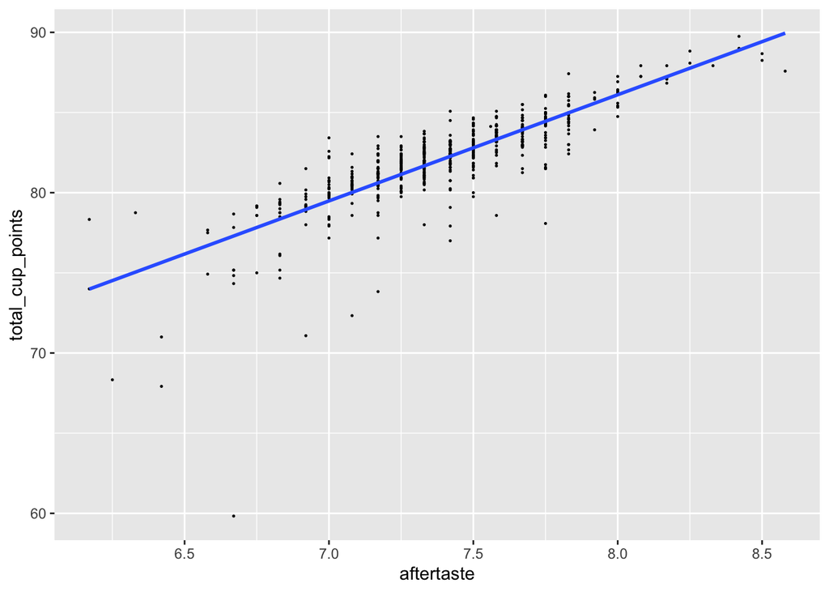

```r
ggplot(new_coffee, aes(y = total_cup_points, x = aftertaste)) +
  geom_point(size = 0.2) +
  geom_smooth(method = "lm", se = FALSE)
```

```r
first_set <- head(coffee_model_df2, 1)
first_set
```

```
##   (Intercept) aftertaste    sigma
## 1    35.07325   6.356896 1.671128
```

```r
beta_0 <- first_set$`(Intercept)`
beta_1 <- first_set$aftertaste
sigma  <- first_set$sigma
set.seed(84735)
one_simulation2 <- new_coffee %>%
  mutate(mu = beta_0 + beta_1 * aftertaste,
         simulated_points = rnorm(572, mean = mu, sd = sigma)) %>%
  select(aftertaste, total_cup_points, simulated_points)
```

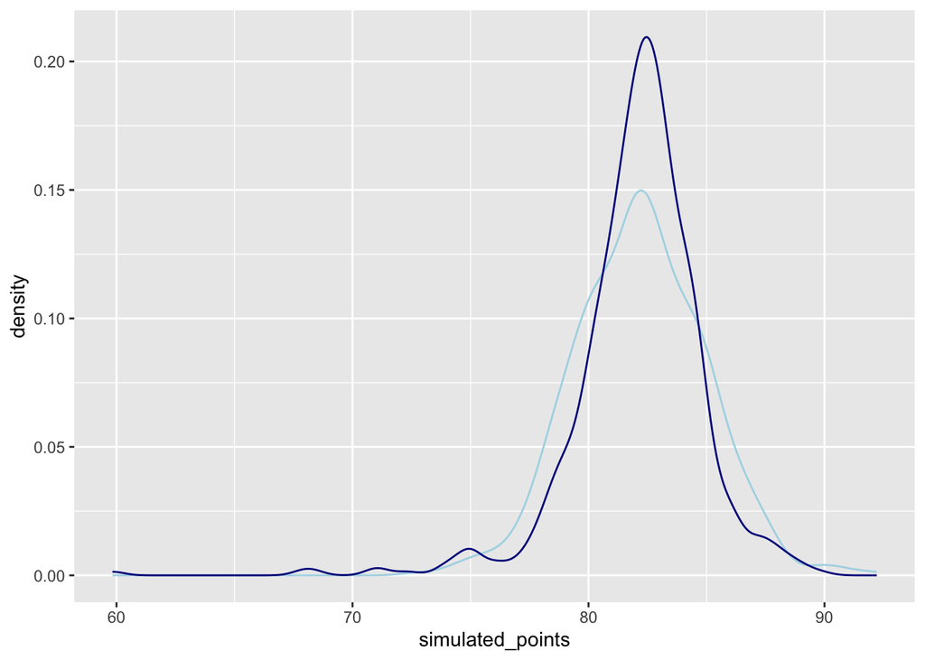

```r
ggplot(one_simulation2, aes(x = simulated_points)) +
  geom_density(color = "lightblue") +
  geom_density(aes(x = total_cup_points), color = "darkblue")
```

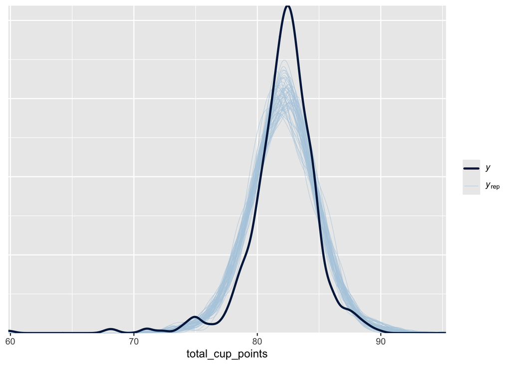

```r
pp_check(coffee_model_posterior2, nreps = 50) +
  xlab("total_cup_points")
```

This model is not wrong as the predictions follows the original points well.

Now we will obtain 10-fold cross-validated measurements of this model’s posterior predictive quality.

```r
set.seed(84735)
cv_procedure <- prediction_summary_cv(
  model = coffee_model_posterior2, data = new_coffee, k = 10)
```

```r
cv_procedure$folds
```

```
##    fold       mae mae_scaled within_50 within_95
## 1     1 0.5360832  0.3326533 0.7586207 0.9827586
## 2     2 0.7010361  0.4481796 0.6842105 0.9473684
## 3     3 0.7811452  0.4805547 0.7719298 1.0000000
## 4     4 0.4103364  0.2543348 0.8596491 0.9649123
## 5     5 0.5425473  0.3896885 0.7192982 0.9473684
## 6     6 0.6987931  0.4379063 0.5964912 0.9649123
## 7     7 0.7955420  0.5081236 0.6842105 0.9298246
## 8     8 0.6734288  0.4292129 0.7368421 0.9649123
## 9     9 0.9508772  0.5925403 0.6315789 1.0000000
## 10   10 0.8153467  0.5156212 0.7068966 0.9655172
```

Putting it all together, I would pick the aftertaste as a useful predictor because looking at the graphs we can see that the predictions follow the original data set better than aroma does.